# Lab 3: Bayes Classifier and Boosting

## Name: Yiyi Miao

## Jupyter notebooks

In this lab, you can use Jupyter https://jupyter.org/ to get a nice layout of your code and plots in one document. However, you may also use Python as usual, without Jupyter.

If you have Python and pip, you can install Jupyter with `sudo pip install jupyter`. Otherwise you can follow the instruction on http://jupyter.readthedocs.org/en/latest/install.html.

And that is everything you need! Now use a terminal to go into the folder with the provided lab files. Then run `jupyter notebook` to start a session in that folder. Click `lab3.ipynb` in the browser window that appeared to start this very notebook. You should click on the cells in order and either press `ctrl+enter` or `run cell` in the toolbar above to evaluate all the expressions.

Be sure to put `%matplotlib inline` at the top of every code cell where you call plotting functions to get the resulting plots inside the document.

## Import the libraries

In Jupyter, select the cell below and press `ctrl + enter` to import the needed libraries. Check out `labfuns.py` if you are interested in the details.

```python
%load_ext autoreload
%autoreload 2
```

```python
import numpy as np
from scipy import misc
# from imp import reload
from importlib import reload
from labfuns import *
import random
```

## Bayes classifier functions to implement

The lab descriptions state what each function should do.

```python
# NOTE: you do not need to handle the W argument for this part!
# in: labels - N vector of class labels
# out: prior - C x 1 vector of class priors
def computePrior(labels, W=None):
    Npts = labels.shape[0]
    if W is None:
        W = np.ones((Npts,1))/Npts
    else:
        assert(W.shape[0] == Npts)
    classes = np.unique(labels)
    Nclasses = np.size(classes)

    prior = np.zeros((Nclasses,1))

    # TODO: compute the values of prior for each class!
    # ==========================
    for jdx, class_label in enumerate(classes):
        # Logical indexing: get the boolean index for all data points
        # belonging to the current class_label
        idx = (labels == class_label).flatten()

        # Calculate the sum of weights for all data points in the current class
        # If W=None, then sum of weights = (1/N) * N_k = N_k / N (i.e., standard frequency)
        # Store the result in the prior vector, where jdx is the class index (0, 1, 2, ...)
        prior[jdx] = np.sum(W[idx]) / np.sum(W)

    # ==========================

    return prior

# NOTE: you do not need to handle the W argument for this part!
# in:      X - N x d matrix of N data points
#     labels - N vector of class labels
# out:    mu - C x d matrix of class means (mu[i] - class i mean)
#      sigma - C x d x d matrix of class covariances (sigma[i] - class i sigma)
def mlParams(X, labels, W=None):
    assert(X.shape[0]==labels.shape[0])
    Npts,Ndims = np.shape(X)
    classes = np.unique(labels)
    Nclasses = np.size(classes)

    if W is None:
        W = np.ones((Npts,1))/float(Npts)

    mu = np.zeros((Nclasses,Ndims))
    sigma = np.zeros((Nclasses,Ndims,Ndims))

    # TODO: fill in the code to compute mu and sigma!
    # ==========================
    for jdx, class_label in enumerate(classes):
        # 1. Data filtering
        idx = (labels == class_label).flatten() # Class K index
        X_k = X[idx, :]                         # Class K data (N_k x d)
        W_k = W[idx, :]                         # Class K weight (N_k x 1)

        W_sum = np.sum(W_k)

        # 2. Calculate mean mu_k
        # Formula: mu_k = (Sum(W_i * X_i)) / W_sum
        # W_k * X_k uses NumPy broadcasting to multiply N_k x 1 by N_k x d, resulting in N_k x d
        mu_k = np.sum(W_k * X_k, axis=0) / W_sum
        mu[jdx, :] = mu_k

        # 3. Calculate diagonal covariance matrix sigma_k (Naive Bayes assumption)

        # Centered data: (X_i - mu_k) => (N_k x d)
        X_k_centered = X_k - mu_k

        # Calculate squared difference: (X_i - mu_k)^2 => (N_k x d)
        X_k_sq_diff = X_k_centered ** 2

        # Calculate the weighted sum of squared differences: Sum(W_i * (X_i - mu_k)^2)
        W_sq_sum = np.sum(W_k * X_k_sq_diff, axis=0)

        # Calculate variance: W_sq_sum / W_sum => (d)
        diag_variance = W_sq_sum / W_sum

        # Create diagonal matrix and store in sigma (d x d)
        # np.diag(variance) creates a matrix with 'variance' elements on the diagonal
        sigma[jdx, :, :] = np.diag(diag_variance)
    # ==========================

    return mu, sigma

# in:      X - N x d matrix of M data points
#      prior - C x 1 matrix of class priors
#         mu - C x d matrix of class means (mu[i] - class i mean)
#      sigma - C x d x d matrix of class covariances (sigma[i] - class i sigma)
# out:     h - N vector of class predictions for test points
def classifyBayes(X, prior, mu, sigma):

    Npts = X.shape[0]
    Nclasses,Ndims = np.shape(mu)
    logProb = np.zeros((Nclasses, Npts))

    # TODO: fill in the code to compute the log posterior logProb!
    # ==========================
    for jdx in range(Nclasses):
        # 1. Extract parameters
        mu_k = mu[jdx, :]          # Mean (d)
        sigma_k = sigma[jdx, :, :] # Coveriance (d x d)

        # 2. Calculate ln(p(k))
        term3 = np.log(prior[jdx, 0])

        # 3. Calculate -0.5 * ln(|Sigma_k|)
        # |Sigma_k| is the product of the diagonal elements. ln(|Sigma_k|) is the sum of the logs of the diagonal elements.
        term1 = -0.5*np.log(np.linalg.det(sigma_k))

        # 4. Calculate the quadratic term -0.5 * (x* - mu_k) * Sigma_k^{-1} * (x* - mu_k)^T

        # X_centered: (X - mu_k) => (N x d)
        X_centered = X - mu_k

        # Sigma_inv_diag: Diagonal elements of Sigma_k^{-1} (d)
        sigma_inv_diag = 1.0 / np.diag(sigma_k)

        # Quadratic term simplification (due to Naive Bayes/diagonal matrix):
        # -0.5 * Sum [ (x_i(m) - mu_k(m))^2 * (1 / Sigma_k(m,m)) ]
        # X_centered^2 is (N x d), sigma_inv_diag is (d)
        # Broadcasting multiplication results in (N x d), then sum along the feature dimension (axis=1) results in (N)
        term2 = -0.5 * np.sum(X_centered**2 * sigma_inv_diag, axis=1)

        # 5. Combine the log discriminant function: logProb[k, n] = term1 + term2[n] + term3
        logProb[jdx, :] = term1 + term2 + term3
    # ==========================

    # one possible way of finding max a-posteriori once
    # you have computed the log posterior
    h = np.argmax(logProb,axis=0)
    return h
```

The implemented functions can now be summarized into the `BayesClassifier` class, which we will use later to test the classifier, no need to add anything else here:

```python
# NOTE: no need to touch this
class BayesClassifier(object):
    def __init__(self):
        self.trained = False

    def trainClassifier(self, X, labels, W=None):
        rtn = BayesClassifier()
        rtn.prior = computePrior(labels, W)
        rtn.mu, rtn.sigma = mlParams(X, labels, W)
        rtn.trained = True
        return rtn

    def classify(self, X):
        return classifyBayes(X, self.prior, self.mu, self.sigma)
```

## Test the Maximum Likelihood estimates

Call `genBlobs` and `plotGaussian` to verify your estimates.

### Assignment 1

- In Assignment 1, we implemented the function mlParams to compute the maximum likelihood estimates of the class means and covariances.
- The dataset generated by genBlobs contains five Gaussian-distributed clusters. Each ellipse in the plot represents the 95% confidence region for one class, defined by its mean and covariance.

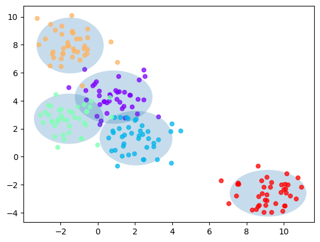

```python
%matplotlib inline

X, labels = genBlobs(centers=5)
mu, sigma = mlParams(X,labels)
plotGaussian(X,labels,mu,sigma)
```

Call the `testClassifier` and `plotBoundary` functions for this part.

```python
testClassifier(BayesClassifier(), dataset='iris', split=0.7)
```

```
Trial: 0 Accuracy 84.4
Trial: 10 Accuracy 95.6
Trial: 20 Accuracy 93.3
Trial: 30 Accuracy 86.7
Trial: 40 Accuracy 88.9
Trial: 50 Accuracy 91.1
Trial: 60 Accuracy 86.7
Trial: 70 Accuracy 91.1
Trial: 80 Accuracy 86.7
Trial: 90 Accuracy 91.1
Final mean classification accuracy  89 with standard deviation 4.16
```

```python
testClassifier(BayesClassifier(), dataset='vowel', split=0.7)
```

```
Trial: 0 Accuracy 61
Trial: 10 Accuracy 66.2
Trial: 20 Accuracy 74
Trial: 30 Accuracy 66.9
Trial: 40 Accuracy 59.7
Trial: 50 Accuracy 64.3
Trial: 60 Accuracy 66.9
Trial: 70 Accuracy 63.6
Trial: 80 Accuracy 62.3
Trial: 90 Accuracy 70.8
Final mean classification accuracy  64.7 with standard deviation 4.03
```

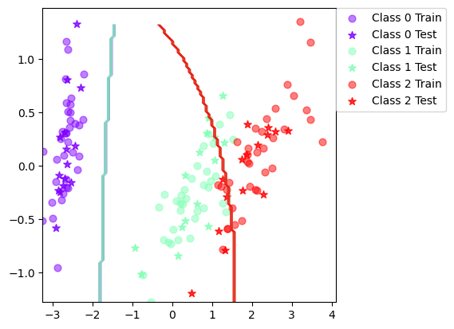

```python
%matplotlib inline
plotBoundary(BayesClassifier(), dataset='iris',split=0.7)
```

```python
# %matplotlib inline
# plotBoundary(BayesClassifier(), dataset='vowel',split=0.7)
```

### Assignment 2 (See code) & 3

| dataset | Final Mean Accuracy | Standard deviation |
| --- | --- | --- |
| Iris | 89 | 4.16 |
| Vowel | 64.7 | 4.03 |

The 2D boundary of Iris dataset is shown in the image:

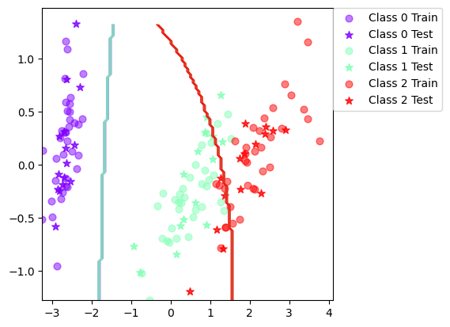

1. When can a feature independence assumption be reasonable and when not?
- The feature independence assumption (used in the Naïve Bayes classifier) assumes that, given the class label, each feature is statistically independent of the others.
- This is reasonable when:
  - The true dependencies between features are weak or the dataset is large enough that small correlation errors don’t dominate.
- It is not reasonable when:
  - Features are strongly correlated or derived from each other, so one feature already gives information about another.
2. How does the decision boundary look for the Iris dataset? How could one improve the classification results for this scenario by changing classifier or, alternatively, manipulating the data?
- There are two boundaries which divide the three classes. The class 0 and 1 are divided by a clear boundary, but class 1 and 2 are divided by a curve where the samples from the two classes overlapped and are misclassified.
- To improve the results, we could use non linear classifier such as SVM with kernel functions, or apply nonlinear transformation to the data.

## Boosting functions to implement

The lab descriptions state what each function should do.

```python
# in: base_classifier - a classifier of the type that we will boost, e.g. BayesClassifier
#                   X - N x d matrix of N data points
#              labels - N vector of class labels
#                   T - number of boosting iterations
# out:    classifiers - (maximum) length T Python list of trained classifiers
#              alphas - (maximum) length T Python list of vote weights
def trainBoost(base_classifier, X, labels, T=10):
    # these will come in handy later on
    Npts,Ndims = np.shape(X)

    classifiers = [] # append new classifiers to this list
    alphas = [] # append the vote weight of the classifiers to this list

    # The weights for the first iteration
    wCur = np.ones((Npts,1))/float(Npts)

    for i_iter in range(0, T):
        # a new classifier can be trained like this, given the current weights
        classifiers.append(base_classifier.trainClassifier(X, labels, wCur))

        # do classification for each point
        vote = classifiers[-1].classify(X)

        # TODO: Fill in the rest, construct the alphas etc.
        # ==========================
        # 1. Identify misclassified points (Boolean N x 1 array)
        is_misclassified = (vote != labels).reshape(-1, 1)

        # 2. Calculate weighted error rate (epsilon)
        # Sum of weights of the misclassified points
        epsilon = np.sum(wCur[is_misclassified])

        # 3. Check for termination conditions
        # If error is too high (>= 0.5) or zero, stop boosting
        if epsilon < 1e-10 or epsilon >= 0.5:
            # Truncate lists to only include successfully trained classifiers/alphas
            classifiers = classifiers[:i_iter + 1]
            alphas = alphas[:i_iter]
            break

        # 4. Calculate classifier vote weight (alpha)
        # alpha = 0.5 * ln((1 - epsilon) / epsilon)
        alpha = 0.5 * (np.log(1.0 - epsilon) - np.log(epsilon))
        alphas.append(alpha) # append the new alpha

        # 5. Update weights (wCur)
        # Correctly classified points: w_new = w_old * exp(-alpha)
        # Misclassified points: w_new = w_old * exp(alpha)

        is_correct = ~is_misclassified # Boolean mask for correct classifications

        # Apply factor exp(-alpha) to correctly classified points
        wCur[is_correct] = wCur[is_correct] * np.exp(-alpha)

        # Apply factor exp(alpha) to misclassified points
        wCur[is_misclassified] = wCur[is_misclassified] * np.exp(alpha)

        # 6. Normalize weights (Z^t)
        # Ensures that the weights sum to 1 for the next iteration
        wCur = wCur / np.sum(wCur)
        # alphas.append(alpha) # you will need to append the new alpha
        # ==========================

    return classifiers, alphas

# in:       X - N x d matrix of N data points
# classifiers - (maximum) length T Python list of trained classifiers as above
#      alphas - (maximum) length T Python list of vote weights
#    Nclasses - the number of different classes
# out:  yPred - N vector of class predictions for test points
def classifyBoost(X, classifiers, alphas, Nclasses):
    Npts = X.shape[0]
    Ncomps = len(classifiers)

    # if we only have one classifier, we may just classify directly
    if Ncomps == 1:
        return classifiers[0].classify(X)
    else:
        votes = np.zeros((Npts,Nclasses))

        # TODO: implement classificiation when we have trained several classifiers!
        # here we can do it by filling in the votes vector with weighted votes
        # ==========================
        # Iterate over all weak classifiers and their vote weights
        for alpha, classifier in zip(alphas, classifiers):

            # Get the prediction (class index) for all test points from the current classifier
            h_t = classifier.classify(X)

            # Accumulate weighted votes
            # This loop iterates through each data point
            for i in range(Npts):
                predicted_class = h_t[i]

                # Add the classifier's weight (alpha) to the tally of the predicted class
                # Votes[i, k] += alpha_t * Indicator(h_t(x_i) == k)
                votes[i, predicted_class] += alpha
        # ==========================

        # one way to compute yPred after accumulating the votes
        return np.argmax(votes,axis=1)
```

The implemented functions can now be summarized another classifer, the `BoostClassifier` class. This class enables boosting different types of classifiers by initializing it with the `base_classifier` argument. No need to add anything here.

```python
# NOTE: no need to touch this
class BoostClassifier(object):
    def __init__(self, base_classifier, T=10):
        self.base_classifier = base_classifier
        self.T = T
        self.trained = False

    def trainClassifier(self, X, labels):
        rtn = BoostClassifier(self.base_classifier, self.T)
        rtn.nbr_classes = np.size(np.unique(labels))
        rtn.classifiers, rtn.alphas = trainBoost(self.base_classifier, X, labels, self.T)
        rtn.trained = True
        return rtn

    def classify(self, X):
        return classifyBoost(X, self.classifiers, self.alphas, self.nbr_classes)
```

## Run some experiments

Call the `testClassifier` and `plotBoundary` functions for this part.

```python
testClassifier(BoostClassifier(BayesClassifier(), T=10), dataset='iris',split=0.7)
```

```
Trial: 0 Accuracy 95.6
Trial: 10 Accuracy 100
Trial: 20 Accuracy 93.3
Trial: 30 Accuracy 91.1
Trial: 40 Accuracy 97.8
Trial: 50 Accuracy 93.3
Trial: 60 Accuracy 93.3
Trial: 70 Accuracy 97.8
Trial: 80 Accuracy 95.6
Trial: 90 Accuracy 93.3
Final mean classification accuracy  94.6 with standard deviation 2.93
```

```python
testClassifier(BoostClassifier(BayesClassifier(), T=10), dataset='vowel',split=0.7)
```

```
Trial: 0 Accuracy 76.6
Trial: 10 Accuracy 85.7
Trial: 20 Accuracy 83.1
Trial: 30 Accuracy 79.9
Trial: 40 Accuracy 72.7
Trial: 50 Accuracy 76
Trial: 60 Accuracy 81.8
Trial: 70 Accuracy 82.5
Trial: 80 Accuracy 79.9
Trial: 90 Accuracy 83.1
Final mean classification accuracy  80.2 with standard deviation 3.42
```

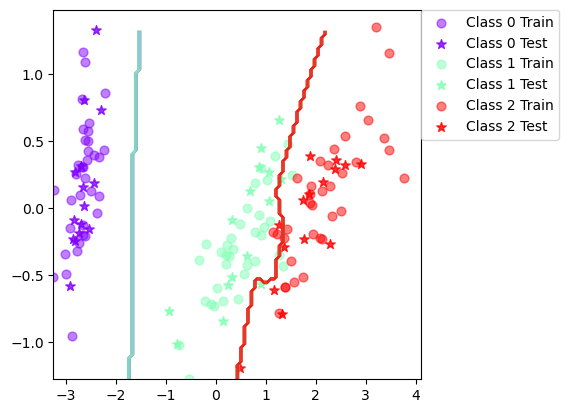

```python
%matplotlib inline
plotBoundary(BoostClassifier(BayesClassifier()), dataset='iris',split=0.7)
```

### Assignment 4 – Weighted `mlParams` Explanation

In Assignment 4, we extended the `mlParams` function to handle **weighted instances**.
The function computes the weighted mean and diagonal covariance for each class, according to the formulas: $$ \mu_k = \frac{\sum w_i x_i}{\sum w_i}, \quad \Sigma_k = \text{diag}\left(\frac{\sum w_i (x_i - \mu_k)^2}{\sum w_i}\right) $$ When the weights are uniform, the results are identical to the previous unweighted version.
This extension is essential for **AdaBoost**, where misclassified samples receive higher weights in subsequent iterations, allowing the model to focus on more difficult examples.

### Assignment 5

1. Is there any improvement in classification accuracy? Why/why not?

| dataset | Final Mean Accuracy | Standard deviation |
| --- | --- | --- |
| Iris (w/o boosting) | 89 | 4.16 |
| Iris (with boosting) | 94.6 | 2.93 |
| Vowel (w/o boosting) | 64.7 | 4.03 |
| Vowel (with boosting) | 80.2 | 3.42 |

- We see significant improvements on both datasets.
  - 89 -> 94.6 for iris, 64.7 -> 80.2 for vowel
  - slightly reduced std

Because the Adaboost algorithm repeatedly updates the weights of the misclassified samples (higher), forcing later classifiers to focus on harder cases.

1. Plot the decision boundary of the boosted classifier on iris and compare it with that of the basic. What differences do you notice? Is the boundary of the boosted version more complex?
- The boundary becomes more complex than the basic one due to the **indentation** between class 1 and class 2. Because the boosted boundary becomes more irregular and adaptive to capture previously misclassified sapmles.

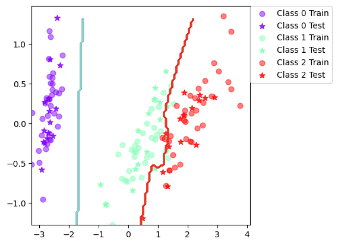

3. Can we make up for not using a more advanced model in the basic classifier(e.g. independent features) by using boosting?
- Partially, yes. Even if the weak learner (e.g., Naïve Bayes) is high-bias, boosting an ensemble can model more complex decision regions and enhance the accuracy.
- But not fully. Boosting cannot fix a wrong probability model (e.g., strong feature correlations that NB ignores) or missing features; it works on the decision rule, not on the correctness of the probabilistic model.

Now repeat the steps with a decision tree classifier.

```python
testClassifier(DecisionTreeClassifier(), dataset='iris', split=0.7)
```

```
Trial: 0 Accuracy 95.6
Trial: 10 Accuracy 100
Trial: 20 Accuracy 91.1
Trial: 30 Accuracy 91.1
Trial: 40 Accuracy 93.3
Trial: 50 Accuracy 91.1
Trial: 60 Accuracy 88.9
Trial: 70 Accuracy 88.9
Trial: 80 Accuracy 93.3
Trial: 90 Accuracy 88.9
Final mean classification accuracy  92.4 with standard deviation 3.71
```

```python
testClassifier(BoostClassifier(DecisionTreeClassifier(), T=10), dataset='iris',split=0.7)
```

```
Trial: 0 Accuracy 95.6
Trial: 10 Accuracy 100
Trial: 20 Accuracy 95.6
Trial: 30 Accuracy 93.3
Trial: 40 Accuracy 93.3
Trial: 50 Accuracy 95.6
Trial: 60 Accuracy 88.9
Trial: 70 Accuracy 93.3
Trial: 80 Accuracy 93.3
Trial: 90 Accuracy 93.3
Final mean classification accuracy  94.6 with standard deviation 3.65
```

```python
testClassifier(DecisionTreeClassifier(), dataset='vowel',split=0.7)
```

```
Trial: 0 Accuracy 63.6
Trial: 10 Accuracy 68.8
Trial: 20 Accuracy 63.6
Trial: 30 Accuracy 66.9
Trial: 40 Accuracy 59.7
Trial: 50 Accuracy 63
Trial: 60 Accuracy 59.7
Trial: 70 Accuracy 68.8
Trial: 80 Accuracy 59.7
Trial: 90 Accuracy 68.2
Final mean classification accuracy  64.1 with standard deviation 4
```

```python
testClassifier(BoostClassifier(DecisionTreeClassifier(), T=10), dataset='vowel',split=0.7)
```

```
Trial: 0 Accuracy 85.7
Trial: 10 Accuracy 87.7
Trial: 20 Accuracy 87.7
Trial: 30 Accuracy 93.5
Trial: 40 Accuracy 84.4
Trial: 50 Accuracy 79.9
Trial: 60 Accuracy 89
Trial: 70 Accuracy 85.7
Trial: 80 Accuracy 86.4
Trial: 90 Accuracy 86.4
Final mean classification accuracy  86.5 with standard deviation 2.91
```

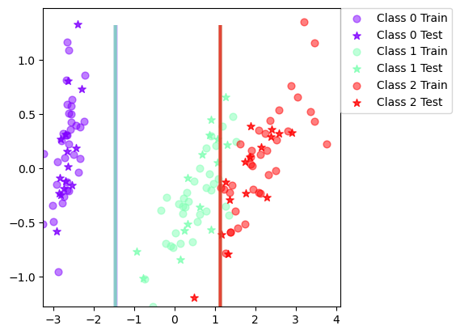

```python
%matplotlib inline
plotBoundary(DecisionTreeClassifier(), dataset='iris',split=0.7)
```

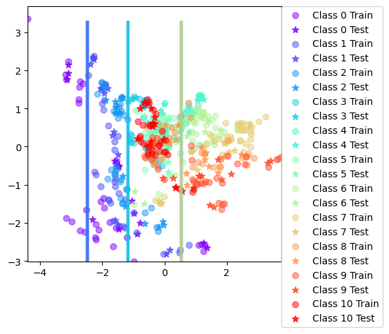

```python
%matplotlib inline
plotBoundary(DecisionTreeClassifier(), dataset='vowel',split=0.7)
```

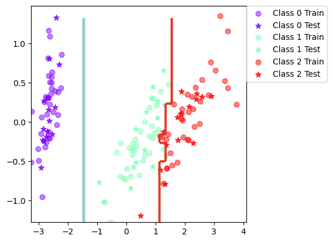

```python
%matplotlib inline
plotBoundary(BoostClassifier(DecisionTreeClassifier(), T=10), dataset='iris',split=0.7)
```

[figure not shown]

```python
%matplotlib inline
plotBoundary(BoostClassifier(DecisionTreeClassifier(), T=10), dataset='vowel',split=0.7)
```

### Assignment 6

1. Is there any improvement in classification accuracy? Why/why not?

| dataset | Final Mean Accuracy | Standard deviation |
| --- | --- | --- |
| Iris (w/o boosting) | 92.4 | 3.71 |
| Iris (with boosting) | 94.6 | 3.65 |
| Vowel (w/o boosting) | 64.1 | 4 |
| Vowel (with boosting) | 86.5 | 2.91 |

decision tree without boosing:

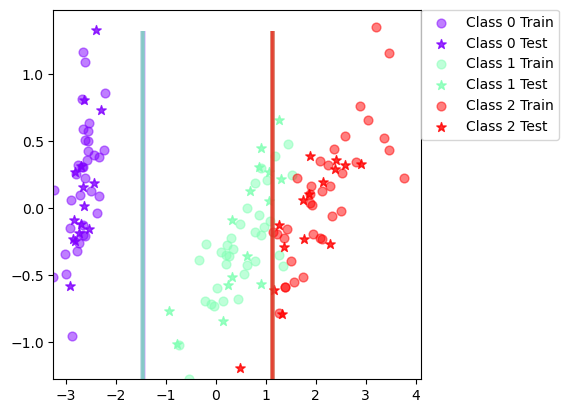

decision tree with boosing:

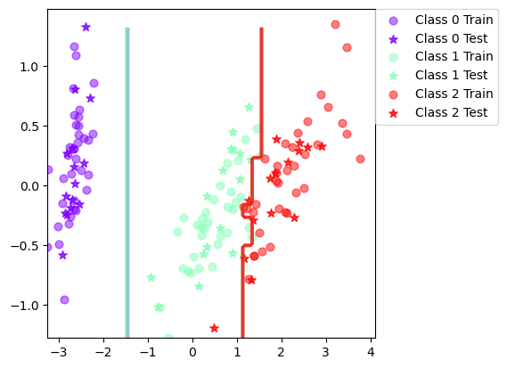

3. Can we make up for not using a more advanced model in the basic classifier(e.g. independent features) by using boosting?
- Still Yes — Each weak tree learns a small part of the true structure; their ensemble can approximate complex boundaries very well. But we should reduce the computation complexity when there is only slight improvement in terms of accuracy.

### Assignment 7

If you had to pick a classifier, naive Bayes or a decision tree or the boosted versions of these, which one would you pick?

- **Outliers**:
  - Decision Tree (DT) is highly robust to outliers, as they use proportional partitioning rather than sensitive distance or mean calculations (which are for Naive Bayes).
  - Boosting can make classifiers less robust, as outliers that remain misclassified receive high weights and force the model to overfit them.
- **Irrelevant Inputs**: part of the feature space is irrelevant
  - The independence assumption in Naive Bayes makes it less sensitive to the irrelevant features in the dataset.
  - If a feature is irrelevant, its class-conditional distributions are nearly identical across all classes, so its log-likelihood contributions cancel out when comparing classes. While the decision tree tend to overfit due to irrelevant features.
- **Predictive Power** :
  - Decision Tree with boosting.
  - Boosting (like Adaboost) combines many weak, biased learners into one strong, highly accurate model.
  - Decision trees are preferred in circumstances where the relationship between features and the target outcome is more complex and non-linear.
  - Naive Bayes is limited by its independence and Gaussian assumptions.
- **Mixed Data Types**: binary, categorical or continuous features, etc.
  - Trees handle binary, categorical, and continuous features in one model.
  - Naive Bayes requires different likelihoods (Gaussian/Bernoulli/Multinomial) for each feature type and assumes independence, making it less flexible.
- **Scalability (large D or N)**: the dimension of the data, D, is large or the number of instances, N, is large, or both.
  - Naive Bayes is better for scalability on very large datasets, as it scales linearly, only needing to count or average feature statistics per class — no sorting, no optimization.
  - Decision Trees must repeatedly sort feature values and evaluate candidate splits, and Boosted Trees multiply this cost by the rounds of iterations T, making them slower for massive datasets.

## Bonus: Visualize faces classified using boosted decision trees

Note that this part of the assignment is completely voluntary! First, let's check how a boosted decision tree classifier performs on the olivetti data. Note that we need to reduce the dimension a bit using PCA, as the original dimension of the image vectors is `64 x 64 = 4096` elements.

```python
testClassifier(BayesClassifier(), dataset='olivetti',split=0.7, dim=20)
```

```
Trial: 0 Accuracy 88.3
Trial: 10 Accuracy 90.8
Trial: 20 Accuracy 85
Trial: 30 Accuracy 89.2
Trial: 40 Accuracy 89.2
Trial: 50 Accuracy 84.2
Trial: 60 Accuracy 91.7
Trial: 70 Accuracy 82.5
Trial: 80 Accuracy 81.7
Trial: 90 Accuracy 86.7
Final mean classification accuracy  87.7 with standard deviation 3.03
```

```python
testClassifier(BoostClassifier(DecisionTreeClassifier(), T=10), dataset='olivetti',split=0.7, dim=20)
```

```
Trial: 0 Accuracy 80.8
Trial: 10 Accuracy 72.5
Trial: 20 Accuracy 78.3
Trial: 30 Accuracy 72.5
Trial: 40 Accuracy 74.2
Trial: 50 Accuracy 69.2
Trial: 60 Accuracy 77.5
Trial: 70 Accuracy 75
Trial: 80 Accuracy 68.3
Trial: 90 Accuracy 68.3
Final mean classification accuracy  70.7 with standard deviation 6.38
```

You should get an accuracy around 70%. If you wish, you can compare this with using pure decision trees or a boosted bayes classifier. Not too bad, now let's try and classify a face as belonging to one of 40 persons!

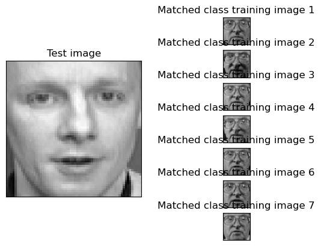

```python
%matplotlib inline
X,y,pcadim = fetchDataset('olivetti') # fetch the olivetti data
xTr,yTr,xTe,yTe,trIdx,teIdx = trteSplitEven(X,y,0.7) # split into training and testing
pca = decomposition.PCA(n_components=20) # use PCA to reduce the dimension to 20
pca.fit(xTr) # use training data to fit the transform
xTrpca = pca.transform(xTr) # apply on training data
xTepca = pca.transform(xTe) # apply on test data
# use our pre-defined decision tree classifier together with the implemented
# boosting to classify data points in the training data
classifier = BoostClassifier(DecisionTreeClassifier(), T=10).trainClassifier(xTrpca, yTr)
yPr = classifier.classify(xTepca)
# choose a test point to visualize
testind = random.randint(0, xTe.shape[0]-1)
# visualize the test point together with the training points used to train
# the class that the test point was classified to belong to
visualizeOlivettiVectors(xTr[yTr == yPr[testind],:], xTe[testind,:])
```